# Quem faz Iniciação Científica?

Relatório de replicação — desigualdades socioeconômicas no acesso à IC na FFLCH-USP (2010–2022)

Autores

Tales Mançano

Victor Alcantara

Data de Publicação

29 de agosto de 2026

Este relatório executa o pacote de replicação e confronta cada resultado com o que foi publicado. Ele não substitui o artigo: serve para que qualquer pessoa verifique, número a número, o que sai dos microdados.

Os dados vêm de dois pedidos de acesso à informação ao SIC-USP: o cadastro de ingressantes da graduação com o questionário socioeconômico da FUVEST (Cod. #243654) e o registro dos projetos de Iniciação Científica no sistema Atena (Cod. #243681).

**ver código**

```r
source(here::here("R", "setup.R"))
source(here::here("R", "recode.R"))

painel <- arrow::read_parquet(ARQ_PAINEL)

fflch <- painel |>
  dplyr::filter(unidade == UNIDADE_FFLCH) |>
  aplicar_recodificacoes() |>
  dplyr::mutate(IC = dplyr::coalesce(IC, 0))

coortes <- dplyr::filter(fflch, ano %in% COORTES)     # 2010-2018
amostra <- dplyr::filter(fflch, ano %in% 2010:2022)   # 2010-2022
```

# 1 O painel

O painel tem uma linha por estudante ingressante na USP, com as variáveis da graduação, as respostas do questionário socioeconômico e o resumo da participação em IC.

**ver código**

```r
data.frame(
  Medida = c("Ingressantes na USP", "Ingressantes na FFLCH (2010–2022)",
             "Estudantes com ao menos uma IC", "Projetos de IC registrados",
             "Variáveis no painel"),
  Valor = format(c(nrow(painel), nrow(amostra),
                   sum(painel$IC == 1, na.rm = TRUE),
                   sum(painel$qtd_ic, na.rm = TRUE),
                   ncol(painel)), big.mark = ".")
)
```

| Medida | Valor |
| --- | --- |
| Ingressantes na USP | 298.704 |
| Ingressantes na FFLCH (2010–2022) | 22.220 |
| Estudantes com ao menos uma IC | 21.902 |
| Projetos de IC registrados | 26.477 |
| Variáveis no painel | 54 |

# 2 Tabela 1 — acesso à IC por coorte

**ver código**

```r
tabela1 <- coortes |>
  dplyr::group_by(ano) |>
  dplyr::summarise(N = dplyr::n(), `Fez IC` = sum(IC), .groups = "drop") |>
  dplyr::mutate(`%` = scales::percent(`Fez IC` / N, accuracy = 0.1))

tabela1
```

| ano | N | Fez IC | % |
| --- | --- | --- | --- |
| 2010 | 1732 | 157 | 9.1% |
| 2011 | 1759 | 147 | 8.4% |
| 2012 | 1694 | 154 | 9.1% |
| 2013 | 1746 | 142 | 8.1% |
| 2014 | 1736 | 198 | 11.4% |
| 2015 | 1691 | 220 | 13.0% |
| 2016 | 1706 | 238 | 14.0% |
| 2017 | 1692 | 233 | 13.8% |
| 2018 | 1704 | 261 | 15.3% |

# 3 Tabela 2 — taxa de resposta do questionário socioeconômico

O QASE foi respondido por 98,55% dos ingressantes, mas o preenchimento por questão é muito desigual. Duas perguntas são inutilizáveis: a ocupação do principal contribuinte da família (19,05%) e o INCLUSP (nenhuma resposta).

**ver código**

```r
questoes <- c(
  estado_civil    = "Estado civil",
  ef1             = "Onde cursou o ensino fundamental",
  ef2             = "Onde cursou o ensino médio",
  em              = "Tipo de ensino médio",
  rfm             = "Renda familiar mensal",
  pessoas_contrib = "Pessoas que contribuem para a renda",
  pessoas_resid   = "Pessoas que vivem da renda",
  atv_remu        = "Exerce atividade remunerada",
  educ_resp1      = "Instrução do responsável 1",
  educ_resp2      = "Instrução do responsável 2",
  ocup_resp1      = "Ocupação do principal contribuinte",
  pretensao_mant  = "Como pretende se manter",
  inclusp         = "Participação no INCLUSP"
)

data.frame(
  `Questão do QASE` = unname(questoes),
  `% de respostas`  = scales::percent(
    vapply(names(questoes), function(v) mean(!is.na(amostra[[v]])), numeric(1)),
    accuracy = 0.01
  ),
  check.names = FALSE, row.names = NULL
)
```

| Questão do QASE | % de respostas |
| --- | --- |
| Estado civil | 71.39% |
| Onde cursou o ensino fundamental | 90.77% |
| Onde cursou o ensino médio | 98.55% |
| Tipo de ensino médio | 98.55% |
| Renda familiar mensal | 98.42% |
| Pessoas que contribuem para a renda | 96.96% |
| Pessoas que vivem da renda | 98.55% |
| Exerce atividade remunerada | 89.59% |
| Instrução do responsável 1 | 97.68% |
| Instrução do responsável 2 | 97.82% |
| Ocupação do principal contribuinte | 19.05% |
| Como pretende se manter | 84.24% |
| Participação no INCLUSP | 0.00% |

# 4 Tabela 4 — modelo logístico

A variável dependente é ter realizado ao menos uma IC. A amostra é a das coortes 2010–2022 com resposta completa nas variáveis do modelo.

**ver código**

```r
md <- amostra |>
  dplyr::select(IC, ano, idade, sexo, raca, educ_resp, sfmpct,
                trabalho, sustento, periodo, class_carreira) |>
  na.exclude()

reg4 <- glm(IC ~ ano + idade + sexo + raca + educ_resp + sfmpct +
              trabalho + sustento + periodo + class_carreira,
            data = md, family = binomial)

coefs <- summary(reg4)$coefficients
data.frame(
  Variável          = rownames(coefs),
  `Valor Z`         = sprintf("%.3f", coefs[, "Estimate"]),
  `Razão de chance` = sprintf("%.3f", exp(coefs[, "Estimate"])),
  `Erro padrão`     = sprintf("%.3f", coefs[, "Std. Error"]),
  `p`               = sprintf("%.3f", coefs[, "Pr(>|z|)"]),
  check.names = FALSE, row.names = NULL
)
```

| Variável | Valor Z | Razão de chance | Erro padrão | p |
| --- | --- | --- | --- | --- |
| (Intercept) | 117.181 | 777906773057892643280804024026608246086442848408888.000 | 15.768 | 0.000 |
| ano | -0.058 | 0.943 | 0.008 | 0.000 |
| idade | -0.060 | 0.942 | 0.007 | 0.000 |
| sexoM | -0.014 | 0.987 | 0.053 | 0.800 |
| racaPPI | -0.138 | 0.871 | 0.066 | 0.035 |
| educ_respEM completo | 0.045 | 1.046 | 0.074 | 0.545 |
| educ_respES completo | 0.068 | 1.070 | 0.076 | 0.371 |
| sfmpct | -0.052 | 0.950 | 0.014 | 0.000 |
| trabalhoSim, em tempo integral | -0.291 | 0.747 | 0.105 | 0.005 |
| trabalhoSim, em tempo parcial | 0.028 | 1.028 | 0.068 | 0.681 |
| sustentoPor conta própria | -0.362 | 0.697 | 0.096 | 0.000 |
| sustentoCom bolsa e apoio da família | 0.227 | 1.255 | 0.070 | 0.001 |
| sustentoCom trabalho e apoio da família | -0.326 | 0.722 | 0.091 | 0.000 |
| sustentoOutros | 0.158 | 1.171 | 0.225 | 0.482 |
| periodonoturno | -0.314 | 0.731 | 0.057 | 0.000 |
| class_carreira | -0.001 | 0.999 | 0.000 | 0.000 |

Os resultados centrais do artigo aparecem aqui: renda familiar per capita e escolaridade dos responsáveis têm efeito pequeno, enquanto trabalhar em tempo integral e pretender se sustentar por conta própria reduzem substantivamente as chances de fazer IC.

## 4.1 Conferência com a tabela publicada

**ver código**

```r
data.frame(
  Estatística = c("Observações", "AIC", "Coef. ano", "Coef. raça (PPI)"),
  Publicado   = c("16.974", "10537,63", "-0,058", "-0,138"),
  Reproduzido = c(format(nobs(reg4), big.mark = "."),
                  sprintf("%.2f", AIC(reg4)),
                  sprintf("%.3f", coef(reg4)[["ano"]]),
                  sprintf("%.3f", coef(reg4)[["racaPPI"]]))
)
```

| Estatística | Publicado | Reproduzido |
| --- | --- | --- |
| Observações | 16.974 | 16.974 |
| AIC | 10537,63 | 10537.63 |
| Coef. ano | -0,058 | -0.058 |
| Coef. raça (PPI) | -0,138 | -0.138 |

# 5 Figuras 1 e 2 — probabilidades preditas

**ver código**

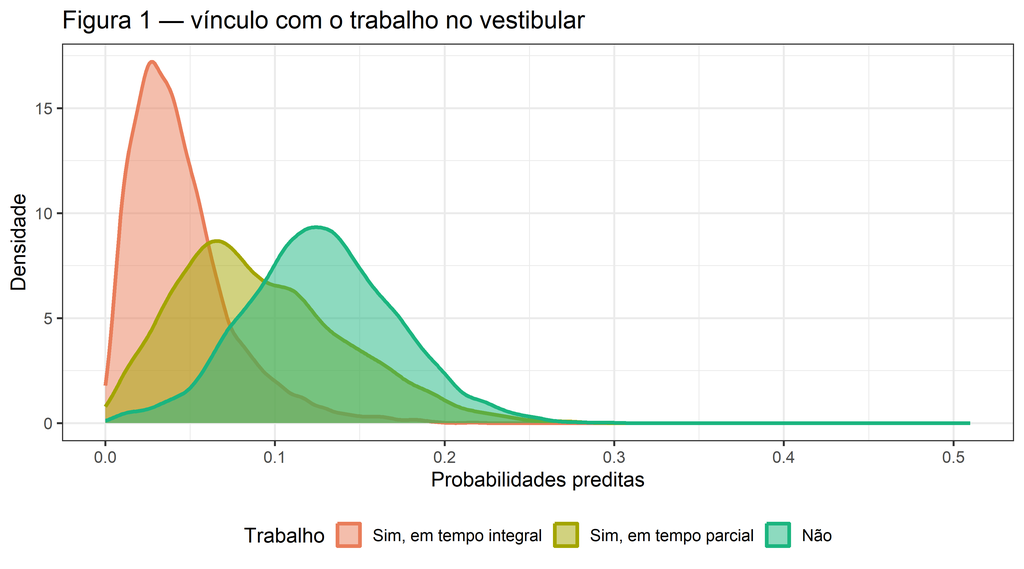

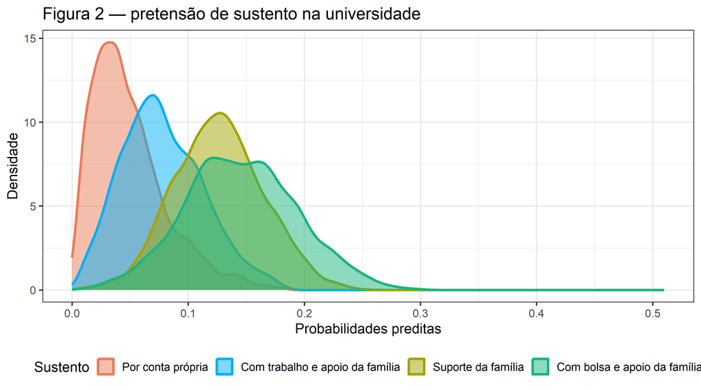

```r
md$p <- predict(reg4, md, type = "response")

tema_densidade <- ggplot2::theme_bw(base_size = 13) +
  ggplot2::theme(legend.position = "bottom")

cores_trabalho <- c("Sim, em tempo integral" = "#e97d5a",
                    "Sim, em tempo parcial"  = "#a3a500",
                    "Não"                    = "#1bb57f")

md |>
  dplyr::mutate(trabalho = factor(trabalho, levels = names(cores_trabalho))) |>
  ggplot2::ggplot(ggplot2::aes(x = p, colour = trabalho, fill = trabalho)) +
  ggplot2::geom_density(linewidth = 1.1, alpha = 0.5) +
  ggplot2::scale_fill_manual(values = cores_trabalho) +
  ggplot2::scale_colour_manual(values = cores_trabalho) +
  ggplot2::scale_x_continuous(limits = c(0, 0.51)) +
  ggplot2::labs(x = "Probabilidades preditas", y = "Densidade",
                colour = "Trabalho", fill = "Trabalho",
                title = "Figura 1 — vínculo com o trabalho no vestibular") +
  tema_densidade
cores_sustento <- c("Por conta própria"               = "#e97d5a",
                    "Com trabalho e apoio da família" = "#00aff6",
                    "Suporte da família"              = "#a3a500",
                    "Com bolsa e apoio da família"    = "#1bb57f")

md |>
  dplyr::filter(sustento != "Outros") |>
  dplyr::mutate(sustento = factor(as.character(sustento),
                                  levels = names(cores_sustento))) |>
  ggplot2::ggplot(ggplot2::aes(x = p, colour = sustento, fill = sustento)) +
  ggplot2::geom_density(linewidth = 1.1, alpha = 0.5) +
  ggplot2::scale_fill_manual(values = cores_sustento) +
  ggplot2::scale_colour_manual(values = cores_sustento) +
  ggplot2::scale_x_continuous(limits = c(0, 0.51)) +
  ggplot2::labs(x = "Probabilidades preditas", y = "Densidade",
                colour = "Sustento", fill = "Sustento",
                title = "Figura 2 — pretensão de sustento na universidade") +
  tema_densidade
```

# 6 Ambiente